# [Algorithmic Fairness](https://www.marcellodibello.com/algorithmicfairness/) – Impossibility Theorems

Marcello Di Bello - ASU - Fall 2021 - Week #6

Our goal is twofold: one, to gain a better understanding of the formal criteria of algorithm fairness; two, to understand the impossibility theorems about algorithmic fairness.

# **Chouldechova’s impossibility theorem**

This theorem relies on two fairness criteria:

Chouldechova (2017), [Fair Prediction With Disparate Impact: A Study of Bias in Recidivism Prediction Instruments](https://arxiv.org/pdf/1703.00056.pdf)

1. Predictive parity
2. Classification parity

## 1. Predictive parity

Predictive parity requires that the Positive Predictive Value (PPV) of the algorithm be the same across groups. We define $PPV$, as follows:

$$PPV = \frac{TP}{TP+FP}$$
where $TP$ stands for True Positive (i.e. the fraction of people who are correctly labeled ‘positive’ *out of all people*) and $FP$ stands for False Positive (i.e. the fraction of people who are incorrectly labeled ‘positive’ *out of all people*).

The denominator refers to all people labeled ‘positive’, whether correctly ($TP$) or incorrectly ($FP$). So, predictive parity—equality in $PPV$ across groups—requires that the fraction of people correctly labeled ‘positive’ *out of all people labeled positive whether correctly or incorrectly* be the same across groups.

## 2. Classification parity

Classification parity requires that the False Negative Rate ($FNR$)—that is, the fraction of people who are incorrectly labeled ‘negative’ *out of all positive people*—and the False Positive Rate ($FPR$)—that is, the fraction of people who are incorrectly labeled ‘positive’ *out of all negative people*)—be the same across groups. Phrased this way, classification parity requires *equality in error rates* across groups.

An equivalent way of defining classification would be this. Classification parity requires that the True Positive Rate ($TPR$)—that is, the fraction of people who are correctly labeled ‘positive’ *out of all positive people*—and the True Negative Rate ($TNR$)—that is, the fraction of people who are correctly labeled ‘negative’ *out of all negative people*—be the same across groups. Phrased this way, classification parity requires *equality in correctness rates* across groups.

So classification parity can be understood as equality in $FNR$ and $FPR$ (equality of error rates) or equality in TPR and TNR (equality in correctness rates). Classification parity can also be defined in a number of other ways, all equivalent, keeping in mind that

Any definition of classification parity will include equality in FPR or TNR, along with equality in FNR or TPR.

$$TPR = 1 - FNR \text{ and } TNR = 1 - FPR.$$

## **The theorem**

*No algorithm can satisfy both predictive parity and classification parity so long as the base rates of the two groups are different.*

## Proof

Even though the theorem isn’t difficult to prove—it is just a rewording of Bayes’ theorem—its significance is profound. It is worth following the proof carefully. The proof consist of two parts.

The **first part** establishes the following claim:

$$\frac{PPV}{1-PPV} =\frac{p}{1-p} \times \frac{1- FNR}{FPR}$$
where $p$ stands for the *base rate* or *prevalence* of the outcome of interest in a given population.

Let’s see why this claim holds. By definition, we know that

$$PPV = \frac{TP}{TP+FP} \tag{*}$$
Notice that

$$TP = p \times TPR \text{ and } FP = (1-p)\times FPR$$
where $TPR$ is True Positive Rate (defined as the fraction of people who are correctly labeled ‘positive’ *out of all positive people*) and $FPR$ is False Positive Rate (defined as the fraction of people who are incorrectly labeled ‘positive’ *out of all negative people*).

After replacing $TP$ by $p \times TPR$ and replacing $FP$ by $(1-p)\times FPR$ in equation (*) above, we get:

If you know Bayes’ theorem, you should recognize it here.

$$PPV = \frac{p \times TPR}{p \times TPR+(1-p)\times FPR}.$$

We analogously define the complement of $PPV$, as follows:

$$1-PPV = \frac{FP}{TP+FP}$$

Thus, by performing the appropriate replacements, we get:

$$1-PPV =\frac{(1-p)\times FPR}{p \times TPR+(1-p)\times FPR}.$$

Finally, we take the ratio of $PPV$ and its complement, as follows:

The rightmost equality uses the fact that $TPR=1-FNR$

$$\frac{PPV}{1-PPV} = \frac{ \frac{p \times TPR}{p \times TPR+(1-p)\times FPR}}{\frac{(1-p)\times FPR}{p \times TPR+(1-p)\times FPR}}=\frac{p}{1-p} \times \frac{TPR}{FPR} = \frac{p}{1-p} \times \frac{1- FNR}{FPR}$$

We are now ready to embark on the **second part** of the proof, the one that establishes the impossibility. The equation we just established holds for any group (indices 1 and 2):

$$\frac{PPV_1}{1-PPV_1}= \frac{p_1}{1-p_1} \times \frac{1-FNR_1}{FPR_1}$$
$$\frac{PPV_2}{1-PPV_2}= \frac{p_2}{1-p_2} \times \frac{1-FNR_2}{FPR_2}$$

By inspecting the two equations, we can see that predictive parity (equality in $PPV$) and classification parity (here understood as equality in error rates, $FNR$ and $FPR$) cannot be concurrently satisfied whenever the base rate or prevalence $p$ differs across groups.

Suppose the base rates of the two groups are different, hence $\frac{p_1}{1-p_1} \neq \frac{p_2}{1-p_2}$. If $\frac{PPV_2}{1-PPV_2}=\frac{PPV_1}{1-PPV_1}$ (predictive parity is satisfied), then $\frac{1-FNR_1}{FPR_1}\neq \frac{1-FNR_2}{FPR_2}$ (classification parity is violated). Conversely, if $\frac{1-FNR_1}{FPR_1} = \frac{1-FNR_2}{FPR_2}$ (classification parity is satisfied), then $\frac{PPV_2}{1-PPV_2} \neq \frac{PPV_1}{1-PPV_1}$ (predictive parity is violated). QED.

## Significance

Chouldechova writes:

> differences in false positive and false negative rates cited as evidence of racial bias by Angwin et al. are a direct consequence of applying an RPI [=Recidivism Prediction Instruments] that that satisfies predictive parity to a population in which recidivism prevalencea differs across groups

As the graph below shows, the group with higher prevalence will experience higher $FPR$ no matter the $FNR$, while holding $PPV$ the same across groups. So the disparities we saw in the COMPAS algorithm cannot—as a mathematical fact—be avoided.

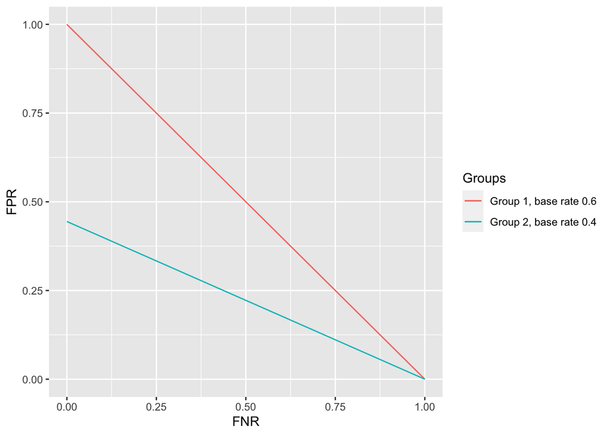

# **Kleinberg et al’s impossibility theorem**

This theorem relies on slightly different fairness criteria:

Kleinberg, Mullainathan and Raghavan (2016), [Inherent Trade-Offs in the Fair Determination of Risk Scores](https://arxiv.org/pdf/1609.05807.pdf)

Intuitvely, the risk score mean the same thing (=likelihood of the outcome, say recidivism) across groups.

3. *Predictive Calibration* - The fraction of positive people *out of those who are assigned the same risk score* is the same across groups. In other words, the score reflects the same likelihood of the outcome across groups.
4. *Classification Balance* - Positive individuals are assigned the same average risk score across groups (positive balance). Negative people are assigned the same average score across groups (negative balance).

Predictive calibration and classification balance are similar to predictive parity and classification parity. But they are criteria for the fairness of algorithmic scores rather than algorithmic decisions. These criteria of fairness can be applied independently of the choice of a decision threshold.

The theorem states that, given different base rates or prevalence across groups, no algorithm can satisfy both predictive calibration and classification balance unless the algorithm achieves perfect prediction. The proof is involved.

# **The Diagonal**

The two impossibility theorems that use four criteria of fairness:

[output not shown]

# **Hellman’s Measurign Algorithmc Fairness**

The starting point of the paper are two families of fairness criteria, those based on equality of predictive value (or predictive accuracy) and those based on equality in error rates. The paper makes three claims: conceptual, normative and legal.

1. Conceptual claim

*Non-comparative*. Predictive value (or predictive accuracy) matters for how we should form our beliefs. For example, if a student passes a test and the test has high predictive accuracy, we should be confident that the student is actually well-prepared. If the test has low predictive accuracy, we should not be confident that the student is actually well-prepared.

*Comparative*. Like predictive accuracy, equal predictive value (EPV) matters for how we should form our beliefs. If a test has less predictive accuracy for men than for women (see example on page 832), we should be less confident that a man who passed the test is actually well-prepared than how confident we should be that a woman who also passed the same test is actually well-prepared.

Does this difference imply that men have been treated unfairly or that women have been treated unfairly? It seems not. Fair treatment pertains to decisions and actions, and instead, equal predictive value guides belief formation.

2. Normative claim

*Non-comparative*. When we make a decision—such as convict someone or put someone in preventative detention—we could make a false positive decision or false negative decision. Before we make a decision, we should weigh the these types of mistakes against one another and strike the right balance between false positives and false negatives.

*Comparative*. Fairness requires that, when we make a decision, we strike the *same balance* between false positives and false negatives across groups. In other words, fairness requires we comply with error ratio parity (ERP). The violation of error ratio parity (ERP) is ‘importantly suggestive’ (p. 836) of unfairness.

Both EPV and ERP are important. An algorithm should probably satisfy both. But only the latter matters for assessing the fairness of decisions and actions. The former matters for forming equally accurate beliefs.

3. Legal claim

One way to improve both EPV and ERP is to improve the informational content of the data that which algorithm uses to assess risk scores. The informational content can be improved by relying on protected classifications such as race or gender in constructing the risk scores.

But isn’t it unconstitutional to explicit rely on protected classifications for making decisions? Wouldn’t that amount to a form of discrimination? US Constitutional anti-discrimination law imposes heightened judicial review (strict scrutiny) for disparate treatment on the basis of protected classifications. But there might be ways to rely on protected classifications in making decisions which do not count as disparate treatment inviting strict scrutiny.

Consider the case of race. For one thing, race-specific decision thresholds would trigger strict scrutiny and be unlikely to pass judicial review. However, using race more indirectly for assigning different weights to other predictors—say, because some predictors are more reliable indicators of the outcome of interest for different racial groups—need not count as disparate treatment on the basis of race.